# Computational Document

이광춘 (KPMG)

2019-11-16

# 1 `tinytex` 팩키지 설치

[`TinyTeX`](https://yihui.org/tinytex/)는 Tex Live에 기반하여 R에서 $\LaTeX$을 윈도우의 경우 220Mbyte, 맥/리눅스의 경우 150MByte까지 작은 크기로 만들어서 PDF 파일을 생성할 수 있도록 만들었다.

다음 명령어로 `tinytex`를 쉽게 설치할 수 있다. `tinytex::uninstall_tinytex()` 명령어는 제거할 때 사용한다.

```r
install.packages('tinytex')
tinytex::install_tinytex() # tinytex::uninstall_tinytex()
```

# 2 `.tex` 헬로월드

`tinytex` PDF 엔진으로 세가지가 있는데, 한글을 사용하시는 CJK 문화권은 `xelatex()`를 권장한다.

- `tinytex::pdflatex()`
- `tinytex::xelatex()`
- `tinytex::lualatex()`

```r
writeLines(c(
  '\\documentclass{article}',
  '\\begin{document}', 'Hello world!', '\\end{document}'
), 'test.tex')

tinytex::pdflatex('test.tex')
```

# 3 `.Rmd` → `.pdf`

`tinytex`를 설치한 후에 `output:`에서 `latex_engine: xelatex`로 지정하고, `pandoc_args`를 지정하여 PDF 파일을 하나로 만든다. 마지막으로 잊지 말아야 할 것이 `mainfont : NanumGothic`로 한글 폰트를 잊지말고 꼭 지정한다.

```r
---
layout: page
title: "Computational Document"
subtitle: "$\LaTeX$ `PDF` 문서"
author:
    name: 이광춘 (KPMG)
    affilates: 데이터 과학자
date: "`r Sys.Date()`"
always_allow_html: yes
output:
    pdf_document :
      latex_engine : xelatex
      pandoc_args:
          - --standalone
mainfont : NanumGothic
editor_options:
  chunk_output_type: console
---
```

```r
library(pdftools)
library(magick)
```

**첫번째 페이지**

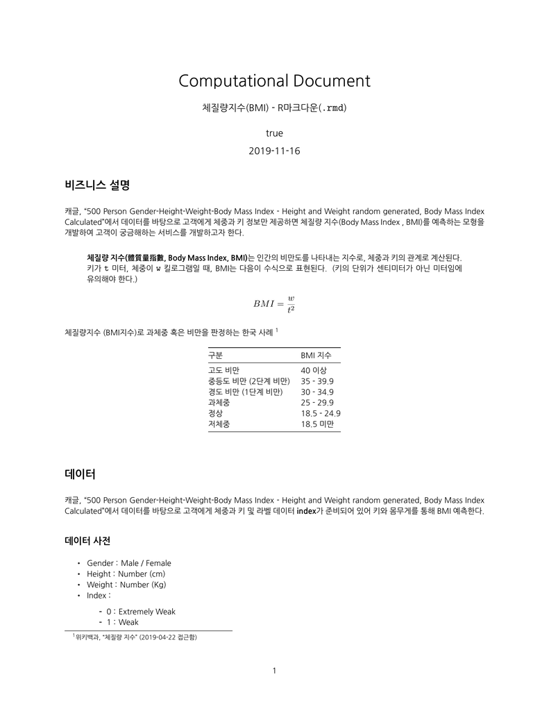

```r
pdf_01 <- pdf_render_page("tutorial/01_rmarkdown/bmi_pdf.pdf", page = 1, dpi = 300, numeric = FALSE)
image_read(pdf_01)
```

**그래프 한글이 포함된 페이지**

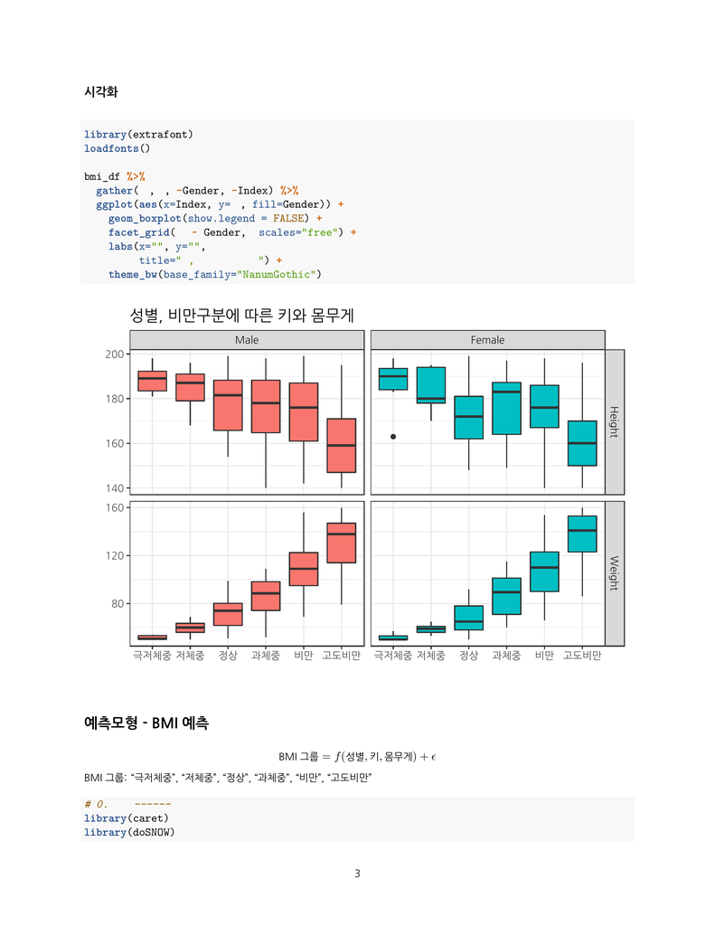

```r
pdf_03 <- pdf_render_page("tutorial/01_rmarkdown/bmi_pdf.pdf", page = 3, dpi = 300, numeric = FALSE)
image_read(pdf_03)
```

만약 `ggplot` 객체로 그대로 `pdf`엔진에 넣으면 한글이 깨지기 때문에 이를 해결하는 방식으로 `cairo_pdf` 혹은 `png` 디바이스를 사용하면 피해갈 수 있다. 즉, 다음과 같이 `dev="cairo_pdf"`을 지정해주면 된다. [^1]

````
```{r bmi-EDA-viz, dev="cairo_pdf"}
library(extrafont)
loadfonts()

bmi_df %>%
  gather(키체중, 값, -Gender, -Index) %>%
  ggplot(aes(x=Index, y= 값, fill=Gender)) +
    geom_boxplot(show.legend = FALSE) +
    facet_grid(키체중 ~ Gender,  scales="free") +
    labs(x="", y="",
         title="성별, 비만구분에 따른 키와 몸무게") +
    theme_bw(base_family="NanumGothic")
```
````

[^1]: [stackoverflow, “RMarkdown not printing Chinese characters in graphs”](https://stackoverflow.com/questions/50957257/rmarkdown-not-printing-chinese-characters-in-graphs)